# Pipeline QM/MM para Umbrella Sampling: completamente automatizado

De datos crudos a ΔG en segundos

Comparto un pipeline para procesar ventanas de Umbrella Sampling, desde RMSD y solapamiento hasta WHAM y PMF, todo automatizado para QMMM PM6/CHARMM.

Dr. Camilo Febres-Molina https://github.com/camilofm (UNAB - Chile)  
2025-11-28

## Introducción

Cuando trabajo con **Umbrella Sampling** acoplado a **QM/MM**, el análisis posterior puede volverse tedioso: copiar archivos desde el clúster, calcular RMSD por ventana, revisar solapamiento, preparar metadata, correr WHAM, limpiar extremos y finalmente obtener el perfil de energía libre (**PMF**).

Y si el proyecto es grande, esto fácilmente se convierte en horas de trabajo repetitivo.

Por eso decidí construir un **pipeline completamente automatizado** que recibe los archivos crudos (`*.rc` y `*_eq.dcd`) y produce **todos los análisis y gráficos finales en aproximadamente 11 segundos**.  
Solo ejecuto:

```bash
bash run_pipeline.sh
```

y obtengo:

- RMSD global, donor y acceptor
- Gráfico de solapamiento de ventanas
- PMF WHAM original
- PMF limpio + spline
- Figuras PNG listas para manuscrito
- Todos los CSV procesados
- HTMLs de diagnóstico
- Todo organizado en una carpeta `resultados/`

Mi intención con este post es compartir la estructura y lógica del pipeline, por si a alguien más le resulta útil.

## ¿Qué hace exactamente el pipeline?

El pipeline ejecuta automáticamente, en orden:

1. **`rmsd_windows.tcl`**  
   Calcula RMSD de la proteína (PROA), donor (DON) y acceptor (ACC) usando VMD.
2. **`rmsd_us_mep-rca.Rmd`**  
   Procesa esos RMSD, genera los gráficos globales y figuras por ventana.
3. **`us_rc_overlap_np.Rmd`**  
   Calcula el solapamiento entre ventanas y genera la figura de densidades.
4. **`gen_metadata.sh`**  
   Construye el metadata que WHAM necesita (centros y constantes de fuerza).
5. **`wham_rca_v6.py`**  
   Ejecuta WHAM 1D y produce el PMF crudo.
6. **`pmf_wham_final.Rmd`**  
   Limpia extremos, recalibra ΔG y genera la versión final con spline.
7. **Copia automática de PNG a `resultados/`**  
   Así no tengo que buscar nada después.

Cada paso queda registrado en `pipeline.log`, lo cual es muy útil para revisar o depurar.

## Resultados generados automáticamente

### RMSD global

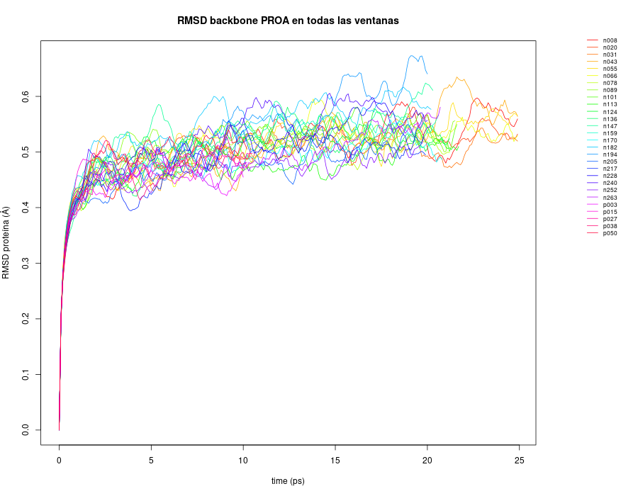

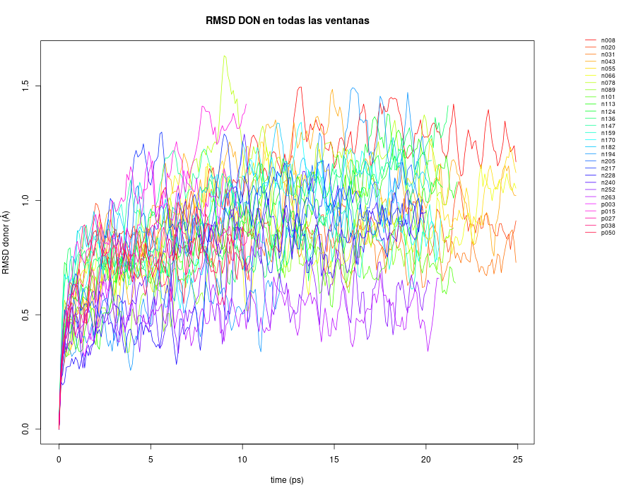

*(Si también generas RMSD global para el acceptor, puedes añadir aquí `rmsd_global_acc.png` de la misma forma.)*

### Solapamiento Umbrella

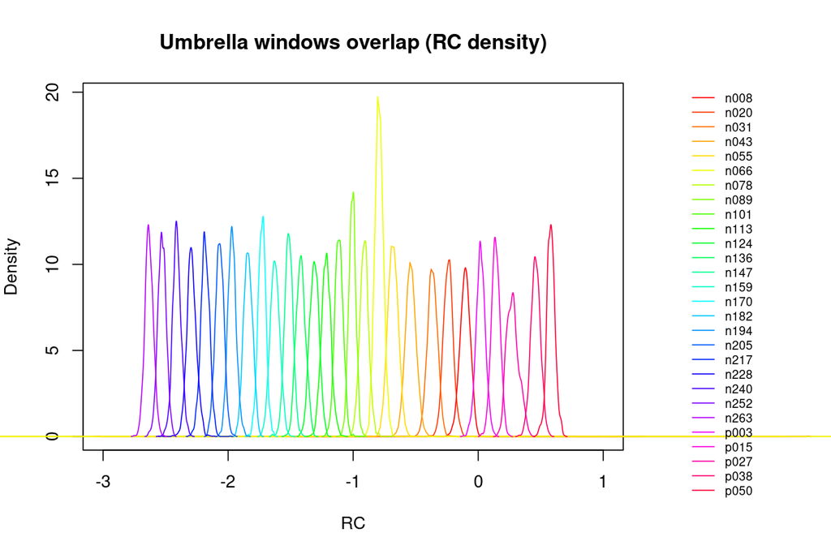

### PMF WHAM (limpio + spline)

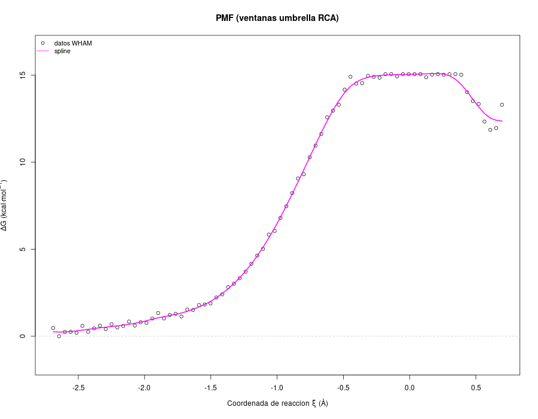

## Arquitectura del script maestro

El corazón del flujo es `run_pipeline.sh`.  
Aquí va un extracto muy simplificado:

```bash
run_step "3. Generar solapamiento de RC"   env RSTUDIO_PANDOC="$PANDOC_BIN"   Rscript -e "rmarkdown::render('us_rc_overlap_np.Rmd', quiet = TRUE)"

run_step "7. Copiar imágenes finales"   bash copy_outputs.sh
```

Todo está encapsulado en funciones y logs, así que si algo falla, el pipeline se detiene mostrando el paso exacto.

## ¿Por qué es útil este pipeline?

Porque evita una gran cantidad de pasos manuales que normalmente dispersan tiempo y energía.

- Evita errores humanos.
- Hace el análisis reproducible.
- Permite reanalizar nuevas ventanas cambiando *solo un comando*.
- Produce figuras de calidad publicable sin intervención manual.
- Sirve como “plantilla” para futuros proyectos similares.

Para mí se convirtió en una herramienta esencial dentro del trabajo QM/MM con enzimas.

## Descarga de los scripts

He subido (o subiré) los archivos del pipeline a un repositorio de GitHub.  
La idea es que puedas clonar el repo, adaptar un par de rutas y usarlo como base para tu propio sistema.

https://github.com/camilofm/umbrella-qmmm-pipeline

## Cierre

Esta versión del pipeline ya es estable y la utilizo a diario.  
Si la adoptas, siéntete libre de modificarla, optimizarla o adaptarla a tus propios sistemas.  
Y si quieres conversar sobre análisis QM/MM, Umbrella Sampling, TREK o rutas de reacción, siempre será un gusto.

*Camilo*